# KNN regression

In this example, we are going to write our own KNN regression model. We are going to assess it using simulated data.

1. Generate $n=200$ paired $(x_i, y_i)$ data points by sampling:

$$\begin{equation}
x_i \sim \mathcal{N}(0, 4)
\end{equation}$$

and then:

$$\begin{equation}
y_i \sim \mathcal{N}(sin(x_i), 0.2)
\end{equation}$$

Visualise your samples.

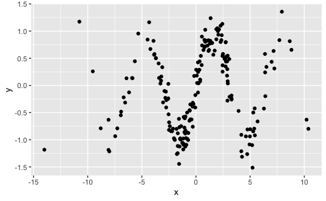

```r
rm(list=ls())
library(tidyverse)
library(reshape2)
library(e1071)
library(RANN)
n <- 200
x <- rnorm(n, 0, 4)
y <- sin(x) + rnorm(n, 0, 0.2)
df <- tibble(x, y) %>%
  mutate(type="actual")
ggplot(df %>% filter(type=="actual"), aes(x=x, y=y)) +
  geom_point()
```

2. Write a function that returns the Euclidean distance of a given $x$ test value from a vector of other $x$ values.

```r
f_eucl_dist <- function(x1, x2) {
  sqrt(sum((x1 - x2)^2))
}
distance <- function(x_test, x_vector) {
  dists <- vector(length=length(x_vector))
  for(i in seq_along(dists))
    dists[i] <- f_eucl_dist(x_vector[i], x_test)
  dists
}
```

3. Write a function which takes as input a given $x$ test value and returns the indices which correspond to the k-nearest neighbours from a set of other $x$ values.

```r
knn_indices <- function(k, x_test, x_vector) {
  dists <- distance(x_test, x_vector)
  low_to_high <- order(dists)[1:k]
  low_to_high
}
```

4. Using your previous function, take the mean of the corresponding $y$ values of the KNN points for a given $x$ test value. This corresponds to a KNN regression function.

```r
kk_regression <- function(k, x_test, x, y) {
  indices <- knn_indices(k, x_test, x)
  mean(y[indices])
}
```

5. For a range of $x$ corresponding to the domain of your simulated data, use your KNN regression model to predict $y$ with $k=10$.

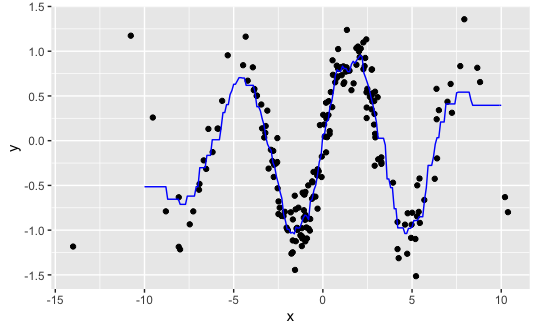

```r
x_sim <- seq(-10, 10, 0.1)
y_sim <- map_dbl(x_sim, ~kk_regression(k=10, ., x, y))
df <- tibble(x, y) %>%
  mutate(type="actual") %>%
  bind_rows(tibble(x=x_sim, y=y_sim) %>% mutate(type="regression"))
ggplot(df %>% filter(type=="actual"), aes(x=x, y=y)) +
  geom_point() +
  geom_line(data=df %>% filter(type=="regression"), colour="blue")
```

6. Try the same thing with $k=1$ and $k=100$. How does choice of $k$ influence the results?

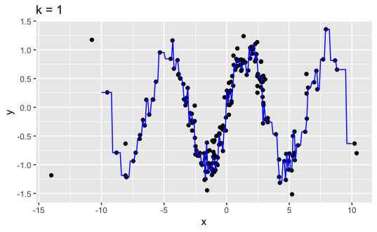

```r
# k = 1
y_sim <- map_dbl(x_sim, ~kk_regression(k=1, ., x, y))
df <- tibble(x, y) %>%
  mutate(type="actual") %>%
  bind_rows(tibble(x=x_sim, y=y_sim) %>% mutate(type="regression"))
ggplot(df %>% filter(type=="actual"), aes(x=x, y=y)) +
  geom_point() +
  geom_line(data=df %>% filter(type=="regression"), colour="blue") +
  ggtitle("k = 1")
```

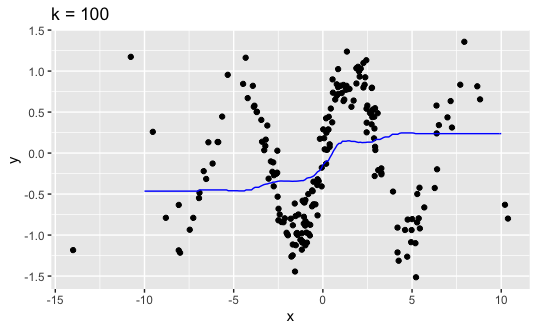

```r
# k = 100
y_sim <- map_dbl(x_sim, ~kk_regression(k=100, ., x, y))
df <- tibble(x, y) %>%
  mutate(type="actual") %>%
  bind_rows(tibble(x=x_sim, y=y_sim) %>% mutate(type="regression"))
ggplot(df %>% filter(type=="actual"), aes(x=x, y=y)) +
  geom_point() +
  geom_line(data=df %>% filter(type=="regression"), colour="blue") +
  ggtitle("k = 100")
```

It is evident that $k$ is a smoothing parameter: too small and the predictions likely overfit the data; too large and they underfit it.